# LM: Tests

2018-05-15

## The Linear Model: LM

- 2.0 Introduction
- 2.1 Point estimates
- 2.2 Uncertainty in point estimates
- 2.3 Tests
- 2.4 Assumptions and Outliers
- 2.5 Let's practice more

## You will learn in this session

- how to use the functions `summary()`, `anova()` and `Anova()`
- that parameters are tested using t-tests
- that you can use LM to do usual Student's t-tests and Pearson correlation tests
- that variables are tested using F-tests or Likelihood Ratio Tests
- how to check the statistical robustness of a test
- how to do a LRT by parametric bootstrap
- that type II ANOVA is the way to go for testing variables
- that doing many tests is dangerous

## The fitted model

## The UK model

```r
(mod_UK1 <- lm(height ~ drink + sex*weight, data = UK))
```

```
##
## Call:
## lm(formula = height ~ drink + sex * weight, data = UK)
##
## Coefficients:
##              (Intercept)            drinkMost days           drinkNot at all  drinkOnce a week or less
##               112.480789                 -0.029830                 -0.476168                 -0.006905
##                  sexGirl                    weight            sexGirl:weight
##                 2.380424                  0.821839                 -0.093667
```

## Testing parameter estimates

## Using the function `summary()`

```r
summary(mod_UK1)
```

```
##
## Call:
## lm(formula = height ~ drink + sex * weight, data = UK)
##
## Residuals:
##      Min       1Q   Median       3Q      Max
## -24.9506  -3.0514  -0.0402   2.9844  26.3810
##
## Coefficients:
##                            Estimate Std. Error t value Pr(>|t|)
## (Intercept)              112.480789   0.470943 238.841  < 2e-16 ***
## drinkMost days            -0.029830   0.464134  -0.064   0.9488
## drinkNot at all           -0.476168   0.226549  -2.102   0.0356 *
## drinkOnce a week or less  -0.006905   0.228409  -0.030   0.9759
## sexGirl                    2.380424   0.565781   4.207 2.60e-05 ***
## weight                     0.821839   0.012871  63.851  < 2e-16 ***
## sexGirl:weight            -0.093667   0.017205  -5.444 5.32e-08 ***
## ---
## Signif. codes:  0 '***' 0.001 '**' 0.01 '*' 0.05 '.' 0.1 ' ' 1
##
## Residual standard error: 4.779 on 11225 degrees of freedom
##   (3643 observations deleted due to missingness)
## Multiple R-squared:  0.4219, Adjusted R-squared:  0.4216
## F-statistic:  1366 on 6 and 11225 DF,  p-value: < 2.2e-16
```

## t-test on parameter estimates

```r
summary(mod_UK1)$coefficient["drinkMost days", ]
```

```
##    Estimate  Std. Error     t value    Pr(>|t|)
## -0.02982985  0.46413433 -0.06426986  0.94875650
```

### Nothing really new: we have seen all this before! (but the p-value)

```r
estimate <- coef(mod_UK1)["drinkMost days"]
std.error <- sqrt(diag(vcov(mod_UK1))["drinkMost days"])
t.value <- (estimate - 0)/std.error
p.value <- 2*pt(abs(t.value), df = mod_UK1$df.residual, lower.tail = FALSE) ## 2x as bilateral test
rbind(estimate, std.error, t.value, p.value)
```

```
##           drinkMost days
## estimate     -0.02982985
## std.error     0.46413433
## t.value      -0.06426986
## p.value       0.94875650
```

## Comparison to the Student's t-test

```r
t.test(extra ~ group, data = sleep, var.equal = TRUE)
```

```
##
##  Two Sample t-test
##
## data:  extra by group
## t = -1.8608, df = 18, p-value = 0.07919
## alternative hypothesis: true difference in means is not equal to 0
## 95 percent confidence interval:
##  -3.363874  0.203874
## sample estimates:
## mean in group 1 mean in group 2
##            0.75            2.33
```

```r
summary(lm(extra ~ group, data = sleep))$coef
```

```
##             Estimate Std. Error  t value   Pr(>|t|)
## (Intercept)     0.75   0.600398 1.249171 0.22760356
## group2          1.58   0.849091 1.860813 0.07918671
```

## Comparing an estimate to a specific value

### Ex: Could the parameter `drinkMost days` be equal to 0.8799548?

```r
new.t.value <- (estimate - 0.8799548)/std.error
2*pt(abs(new.t.value), df = mod_UK1$df.residual, lower.tail = FALSE)
```

```
## drinkMost days
##     0.05000001
```

```r
library(car)
## this uses a F-test, but similar (see later)
linearHypothesis(mod_UK1, c("drinkMost days = 0.8799548"))$"Pr(>F)"[2]
```

```
## [1] 0.05000001
```

Notice:

```r
confint(mod_UK1, parm = "drinkMost days")
```

```
##                     2.5 %    97.5 %
## drinkMost days -0.9396145 0.8799548
```

## Comparison to the one sample Student's t-test

```r
set.seed(1L)
y <- rnorm(10, mean = 2)
t.test(y, mu = 2)$p.value
```

```
## [1] 0.6052327
```

```r
summary(lm(y ~ 1 + offset(rep(2, 10))))$coef
```

```
##              Estimate Std. Error   t value  Pr(>|t|)
## (Intercept) 0.1322028   0.246843 0.5355745 0.6052327
```

## Comparison to Pearson's correlation test

```r
x <- c(44.4, 45.9, 41.9, 53.3, 44.7, 44.1, 50.7, 45.2, 60.1) ## from ?cor.test
y <- c( 2.6,  3.1,  2.5,  5.0,  3.6,  4.0,  5.2,  2.8,  3.8)
c(rho = cor(y, x), pv = cor.test(y, x)$p.value)
```

```
##       rho        pv
## 0.5711816 0.1081731
```

```r
summary(lm(y ~ x))$coef["x", ]
```

```
##   Estimate Std. Error    t value   Pr(>|t|)
## 0.09718095 0.05278468 1.84108264 0.10817305
```

```r
cov(x,y)/(sd(x)*sd(y)) # definition of rho
```

```
## [1] 0.5711816
```

```r
coef(lm(y~x))["x"] * sd(x)/sd(y)  ## because slope = cov(x, y)/var(x)
```

```
##         x
## 0.5711816
```

## Comparing the fitted model to the fit of a null model

## Using the function `anova()`

```r
mod_UK0 <- lm(height ~ 1, data = mod_UK1$model) ## we use model frame to keep same dataset
anova(mod_UK0, mod_UK1)  ## same line as the last one from summary(mod_UK1)
```

```
## Analysis of Variance Table
##
## Model 1: height ~ 1
## Model 2: height ~ drink + sex * weight
##   Res.Df    RSS Df Sum of Sq      F    Pr(>F)
## 1  11231 443561
## 2  11225 256402  6    187158 1365.6 < 2.2e-16 ***
## ---
## Signif. codes:  0 '***' 0.001 '**' 0.01 '*' 0.05 '.' 0.1 ' ' 1
```

### This test should always be performed first before testing estimates individually!

## The F-test step by step

```r
anova(mod_UK0, mod_UK1)
```

```
## Analysis of Variance Table
##
## Model 1: height ~ 1
## Model 2: height ~ drink + sex * weight
##   Res.Df    RSS Df Sum of Sq      F    Pr(>F)
## 1  11231 443561
## 2  11225 256402  6    187158 1365.6 < 2.2e-16 ***
## ---
## Signif. codes:  0 '***' 0.001 '**' 0.01 '*' 0.05 '.' 0.1 ' ' 1
```

```r
c(df = df <- 11231 - 11225, SS = SS <- 443561 - 256402, F = F <- (SS/df) / (256402/11225))
```

```
##         df         SS          F
##      6.000 187159.000   1365.603
```

```r
SS/df  ## mean square treatment = var between = loss in estimated error variance
```

```
## [1] 31193.17
```

## The F-test step by step

```r
anova(mod_UK0, mod_UK1)
```

```
## Analysis of Variance Table
##
## Model 1: height ~ 1
## Model 2: height ~ drink + sex * weight
##   Res.Df    RSS Df Sum of Sq      F    Pr(>F)
## 1  11231 443561
## 2  11225 256402  6    187158 1365.6 < 2.2e-16 ***
## ---
## Signif. codes:  0 '***' 0.001 '**' 0.01 '*' 0.05 '.' 0.1 ' ' 1
```

```r
c(df = df <- 11231 - 11225, SS = SS <- 443561 - 256402, F = F <- (SS/df) / (256402/11225))
```

```
##         df         SS          F
##      6.000 187159.000   1365.603
```

```r
c(256402/11225, summary(mod_UK1)$sigma^2)  ## mean square error = var within = estimate of error variance
```

```
## [1] 22.84205 22.84209
```

## The F-test step by step

```r
anova(mod_UK0, mod_UK1)
```

```
## Analysis of Variance Table
##
## Model 1: height ~ 1
## Model 2: height ~ drink + sex * weight
##   Res.Df    RSS Df Sum of Sq      F    Pr(>F)
## 1  11231 443561
## 2  11225 256402  6    187158 1365.6 < 2.2e-16 ***
## ---
## Signif. codes:  0 '***' 0.001 '**' 0.01 '*' 0.05 '.' 0.1 ' ' 1
```

```r
c(df = df <- 11231 - 11225, SS = SS <- 443561 - 256402, F = F <- (SS/df) / (256402/11225))
```

```
##         df         SS          F
##      6.000 187159.000   1365.603
```

```r
(p.value <- 1 - pf(F, df1 = 6, df2 = 11225))
```

```
## [1] 0
```

## The likelihood ratio test

```r
mod_UK2 <- lm(height ~ milk, data = UK)
mod_UK0 <- lm(height ~ 1, data = mod_UK2$model)
anova(mod_UK0, mod_UK2, test = "Chisq")  ## does not show the statistic :-(
```

```
## Analysis of Variance Table
##
## Model 1: height ~ 1
## Model 2: height ~ milk
##   Res.Df    RSS Df Sum of Sq Pr(>Chi)
## 1  10508 445810
## 2  10507 445712  1     98.32   0.1279
```

```r
stat <- 2*(c(logLik(mod_UK2)) - c(logLik(mod_UK0)))
1 - pchisq(stat, df = 1)  ## df = K model 1 - K model 2
```

```
## [1] 0.1278894
```

```r
anova(mod_UK0, mod_UK2, test = "F")[2, "Pr(>F)"]  ## for LM F-test and LRT are equivalent!
```

```
## [1] 0.1279348
```

## Comparing two nested models

## t-test and F-test are equivalent for quantit var

```r
mod_UK3 <- lm(height ~ milk + sex*weight, data = UK)
summary(mod_UK3)$coefficient["milk", ]
```

```
##   Estimate Std. Error    t value   Pr(>|t|)
## 0.03655124 0.02769290 1.31987752 0.18690601
```

```r
mod_UK3_no_milk <- lm(height ~ sex*weight, data = mod_UK3$model)
anova(mod_UK3_no_milk, mod_UK3)
```

```
## Analysis of Variance Table
##
## Model 1: height ~ sex * weight
## Model 2: height ~ milk + sex * weight
##   Res.Df    RSS Df Sum of Sq      F Pr(>F)
## 1  10040 227634
## 2  10039 227595  1    39.495 1.7421 0.1869
```

```r
round(summary(mod_UK3)$coefficient["milk", "t value"]^2-anova(mod_UK3_no_milk, mod_UK3)$F[2], 2) ## t^2 = F
```

```
## [1] 0
```

## Nested model comparison allows for testing the overall effect of several parameters

```r
mod_UK1 <- lm(height ~ drink + sex*weight, data = UK)
mod_UK1_no_weight <- lm(height ~ drink + sex, data = mod_UK1$model)
anova(mod_UK1_no_weight, mod_UK1)
```

```
## Analysis of Variance Table
##
## Model 1: height ~ drink + sex
## Model 2: height ~ drink + sex * weight
##   Res.Df    RSS Df Sum of Sq      F    Pr(>F)
## 1  11227 442409
## 2  11225 256402  2    186007 4071.6 < 2.2e-16 ***
## ---
## Signif. codes:  0 '***' 0.001 '**' 0.01 '*' 0.05 '.' 0.1 ' ' 1
```

## Nested model comparison thus allows for testing the overall effect of a qualitative variable

```r
mod_UK1 <- lm(height ~ drink + sex*weight, data = UK)
mod_UK1_no_alcool <- lm(height ~ sex*weight, data = mod_UK1$model)
anova(mod_UK1_no_alcool, mod_UK1)
```

```
## Analysis of Variance Table
##
## Model 1: height ~ sex * weight
## Model 2: height ~ drink + sex * weight
##   Res.Df    RSS Df Sum of Sq      F    Pr(>F)
## 1  11228 257020
## 2  11225 256402  3    617.44 9.0102 5.889e-06 ***
## ---
## Signif. codes:  0 '***' 0.001 '**' 0.01 '*' 0.05 '.' 0.1 ' ' 1
```

## Testing all variables in one go with `anova()`

### Sequential test: Type 1 ANOVA (dangerous)

```r
anova(mod_UK1)
```

```
## Analysis of Variance Table
##
## Response: height
##               Df Sum Sq Mean Sq   F value    Pr(>F)
## drink          3    940     313   13.7182 6.285e-09 ***
## sex            1    211     211    9.2427   0.00237 **
## weight         1 185330  185330 8113.5341 < 2.2e-16 ***
## sex:weight     1    677     677   29.6384 5.316e-08 ***
## Residuals  11225 256402      23
## ---
## Signif. codes:  0 '***' 0.001 '**' 0.01 '*' 0.05 '.' 0.1 ' ' 1
```

## Testing all variables in one go with `Anova()`

### Marginal test: Type 2 ANOVA (recommended)

```r
library(car)
Anova(mod_UK1)
```

```
## Anova Table (Type II tests)
##
## Response: height
##            Sum Sq    Df   F value    Pr(>F)
## drink         617     3    9.0102 5.889e-06 ***
## sex          1220     1   53.4139 2.885e-13 ***
## weight     185330     1 8113.5341 < 2.2e-16 ***
## sex:weight    677     1   29.6384 5.316e-08 ***
## Residuals  256402 11225
## ---
## Signif. codes:  0 '***' 0.001 '**' 0.01 '*' 0.05 '.' 0.1 ' ' 1
```

Note : test of simple terms consider other simple terms to be there, but not interactions.

Tip: never use type 3 ANOVA!

## Robustness of the F test

```r
set.seed(1L)
pv.F <- replicate(200, {
  mod_UK1$model$height_no_alcool <- as.matrix(simulate(mod_UK1_no_alcool))
  mod_alcool_fooled <- lm(height_no_alcool ~ drink + sex*weight, data = mod_UK1$model)
  mod_alcool_not_fooled <- lm(height_no_alcool ~ sex*weight, data = mod_UK1$model)
  anova(mod_alcool_not_fooled, mod_alcool_fooled)[2, "Pr(>F)"]
})
mean(pv.F <= 0.05)
```

```
## [1] 0.045
```

## Robustness of the F test

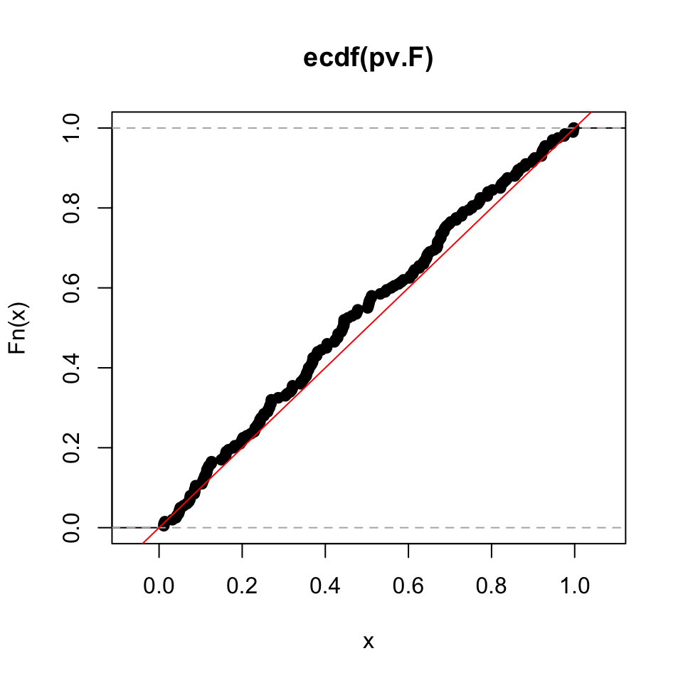

```r
plot(ecdf(pv.F))
abline(0, 1, col = "red")  ## uniform reference
```

## LRT by parametric boostrap

```r
mod_UK_milk <- lm(height ~ milk + sex*weight, data = UK)
mod_UK_no_milk <- lm(height ~ sex*weight, data = mod_UK_milk$model)
anova(mod_UK_no_milk, mod_UK_milk, test = "Chisq")[2, "Pr(>Chi)"]
```

```
## [1] 0.1868759
```

```r
(stat.obs <- 2*(c(logLik(mod_UK_milk)) - c(logLik(mod_UK_no_milk))))
```

```
## [1] 1.742793
```

```r
stat.rand <- replicate(1000, {
  newY <- as.matrix(simulate(mod_UK_no_milk))
  mod_milk <- lm(newY ~ milk + sex*weight, data = mod_UK_milk$model)
  mod_no_milk <- lm(newY ~ sex*weight, data = mod_UK_milk$model)
  c(2*(logLik(mod_milk) - logLik(mod_no_milk)))
  })

(sum(stat.rand >= stat.obs) + 1) / (length(stat.rand) + 1)
```

```
## [1] 0.1838162
```

## LRT by parametric boostrap

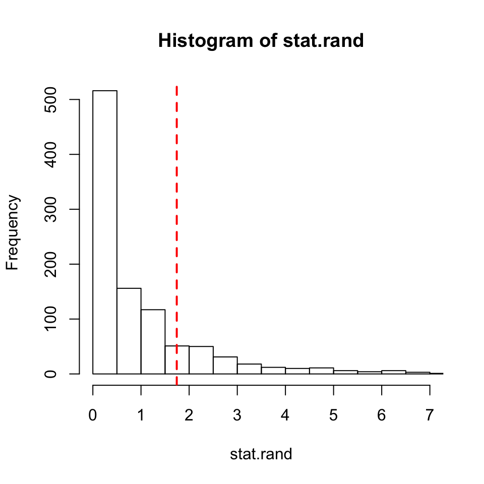

```r
hist(stat.rand, nclass = 50, xlim = c(0, 7))
abline(v = stat.obs, lwd = 2, lty = 2, col = "red")
```

## LRT by parametric boostrap using spaMM

```r
mod_UK_milk_spaMM    <- fitme(height ~ milk + sex*weight, data = UK)
mod_UK_no_milk_spaMM <- fitme(height ~ sex*weight, data = mod_UK_milk_spaMM$data)
LRT(mod_UK_milk_spaMM, mod_UK_no_milk_spaMM, boot.repl = 200)
```

```
## Bootstrap replicates: bootstrap took 195.5 s.
```

```
##      chi2_LR df   p_value
## p_v 1.742793  1 0.1867853
##  ======== Bootstrap: ========
## Raw simulated p-value: 0.259
## Bartlett-corrected LR test:
##      chi2_LR df  p_value
## p_v 1.483607  1 0.223211
```

## Comparing two non-nested models (with same response!)

## Comparing two non-nested models using deviance

You may use the deviance (smaller is better) or (log)likelihood (bigger is better), but only if the number of residual degrees of freedom is the same

```r
UK_for_both <- na.omit(UK[, c("height", "cigarettes", "sex", "weight", "milk")])
mod_UK1 <- lm(height ~ cigarettes + sex*weight, data = UK_for_both)
mod_UK5 <- lm(height ~ milk + sex*weight, data = UK_for_both)

deviance(mod_UK1)
```

```
## [1] 224921.9
```

```r
deviance(mod_UK5)
```

```
## [1] 227594.9
```

## Comparing two non-nested models using AIC

You may use the AIC (AIC = -2 * (logLik - K)) (smaller is better) even if the number of residual degrees of freedom differ.

```r
AIC(mod_UK1)
```

```
## [1] 59740.2
```

```r
AIC(mod_UK5)
```

```
## [1] 59858.86
```

The smaller the AIC the better!

## Comparing two non-nested models using adjusted R-squared

You may use ajusted R-squared (higher is better) even if the number of residual degrees of freedom differ, but it is not a valid statistical model comparison technic.

```r
summary(mod_UK1)$adj.r.squared
```

```
## [1] 0.4244949
```

```r
SST <- sum((fitted(mod_UK1) - mean(fitted(mod_UK1)))^2)
SSR <- sum((residuals(mod_UK1) - mean(residuals(mod_UK1)))^2)
(r.squared <- SST/(SST + SSR))  ## Note: SST+SSR = sum((mod_UK1$model$height - mean(mod_UK1$model$height))^2)
```

```
## [1] 0.4247241
```

```r
1 - (1 - r.squared) * ((nrow(mod_UK1$model) - 1)/mod_UK1$df.residual)  ## adjusted r-squared
```

```
## [1] 0.4244949
```

```r
summary(mod_UK5)$adj.r.squared
```

```
## [1] 0.4176555
```

## Comparing two non-nested models using parametric bootstrap

### This is the best method as it deals with uncertainty. It also gives a p-value.

We consider one model as the null model of the other (we choose here the worse model)

```r
set.seed(1L)
(LRTobs <- 2*(logLik(mod_UK1)[[1]] - logLik(mod_UK5)[[1]]))
```

```
## [1] 118.661
```

```r
LRTH0 <- replicate(200, {
                    UK_for_both$height <- simulate(mod_UK5)[, 1]
                    2*(logLik(update(mod_UK1))[[1]] -
                      logLik(update(mod_UK5))[[1]])
                    })
(sum(LRTH0 >= LRTobs) + 1) / (length(LRTH0) + 1)
```

```
## [1] 0.004975124
```

## Comparing two non-nested models using parametric bootstrap using spaMM

```r
mod_UK1_spaMM <- fitme(height ~ cigarettes + sex*weight, data = UK_for_both)
mod_UK5_spaMM <- fitme(height ~ milk + sex*weight, data = UK_for_both)
LRTUK5null_obs <- 2*(logLik(mod_UK1_spaMM) - logLik(mod_UK5_spaMM))
refit_mod <- function(y, data, mod_null, mod_full, ...) {
  data$height <- y  ## replace original response by response simulated under mod_null
  mod_full_under_null <- update(mod_full, data = data)
  mod_null_under_null <- update(mod_null, data = data)
  2*(logLik(mod_full_under_null) - logLik(mod_null_under_null))
}
LRTUK5null_boot <- spaMM_boot(mod_UK5_spaMM, simuland = refit_mod, nsim = 200,
                              data = UK_for_both, mod_null = mod_UK5_spaMM,
                              mod_full = mod_UK1_spaMM)[["bootreps"]]
```

```
## Bootstrap replicates: bootstrap took 197.4 s.
```

```r
(sum(LRTUK5null_boot >= LRTUK5null_obs) + 1) / (length(LRTUK5null_boot) + 1)
```

```
## [1] 0.004975124
```

## Comparing too many things

## Simulate nothingness

```r
simu_null <- function(N, K) {
  d <- as.data.frame(replicate(K + 1, rnorm(N)))
  colnames(d)[1] <- "y"
  colnames(d)[2:(K + 1)] <- paste0("x", 1:K)
  return(d)
}

set.seed(1L)
simu_null(N = 5, K = 3)
```

```
##            y         x1         x2          x3
## 1 -0.6264538 -0.8204684  1.5117812 -0.04493361
## 2  0.1836433  0.4874291  0.3898432 -0.01619026
## 3 -0.8356286  0.7383247 -0.6212406  0.94383621
## 4  1.5952808  0.5757814 -2.2146999  0.82122120
## 5  0.3295078 -0.3053884  1.1249309  0.59390132
```

## Testing nothingness

```r
K <- 3
set.seed(1L)
lm(y ~ ., data = simu_null(N = 5, K = K))
```

```
##
## Call:
## lm(formula = y ~ ., data = simu_null(N = 5, K = K))
##
## Coefficients:
## (Intercept)           x1           x2           x3
##      0.5301      -0.7359      -0.7775      -0.5912
```

```r
set.seed(1L)
(p.values <- Anova(lm(y ~ ., data = simu_null(N = 5, K = K)))["Pr(>F)"][1:K, 1])
```

```
## [1] 0.7249864 0.5093511 0.8115190
```

```r
min(p.values) <= 0.05
```

```
## [1] FALSE
```

## Comparing many estimates/models decreases the robustness!!!

```r
set.seed(1L)
mean(replicate(200, min(Anova(lm(y ~ ., data = simu_null(N = 100, K = 1)))["Pr(>F)"][1, 1]) <= 0.05))
```

```
## [1] 0.07
```

```r
mean(replicate(200, min(Anova(lm(y ~ ., data = simu_null(N = 100, K = 3)))["Pr(>F)"][1:3, 1]) <= 0.05))
```

```
## [1] 0.14
```

```r
mean(replicate(200, min(Anova(lm(y ~ ., data = simu_null(N = 100, K = 10)))["Pr(>F)"][1:10, 1]) <= 0.05))
```

```
## [1] 0.365
```

```r
mean(replicate(200, min(Anova(lm(y ~ ., data = simu_null(N = 1000, K = 50)))["Pr(>F)"][1:50, 1]) <= 0.05))
```

```
## [1] 0.92
```

## Why not do backward selection?

```r
backward <- function(k, nsimu = 100) {
  pv.signif.rec <- matrix(rep(NA, 2*nsimu), nrow = 2)
  row.names(pv.signif.rec) <- c("full", "backward")
  for (i in 1:nsimu) {
    d <- simu_null(N = nsimu, K = k)
    mod.full <- lm(y ~ ., data = d)
    mod.null <- lm(y ~ 1, data = d)
    mod.backward <- step(mod.full, direction = "backward", trace = FALSE)
    pv.full <- anova(mod.null, mod.full)$Pr[2]
    pv.backward <- anova(mod.null, mod.backward)$Pr[2]
    pv.signif.rec["full", i] <- ifelse(is.na(pv.full), FALSE, pv.full <= 0.05)
    pv.signif.rec["backward", i] <- ifelse(is.na(pv.backward), FALSE, pv.backward <= 0.05)}
  return(apply(pv.signif.rec, 1, mean))
}

result_backward <- sapply(c(3, 5, 10, 15, 20, 50), function(i) {backward(k = i)})
```

## Why not do backward selection?

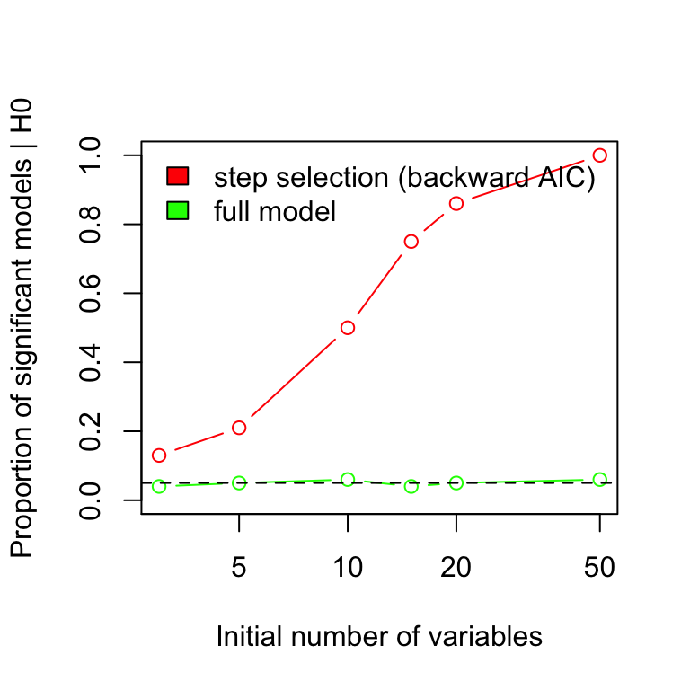

```r
plot(result_backward["full", ] ~ c(3, 5, 10, 15, 20, 50),
  type = "b", col = "green", ylim = c(0, 1), xlab = "Initial number of variables",
  ylab = "Proportion of significant models | H0", log = "x")
points(result_backward["backward", ] ~ c(3, 5, 10, 15, 20, 50), type = "b", col = "red")
abline(h = 0.05, lty = 2)
legend("topleft", fill = c("red", "green"), legend = c("step selection (backward AIC)", "full model"), bty = "n")
```

## What shall I do?

- Don't go fishing (forget backward selection!!!)
- Always compare the fit to null model fit and do not do more tests if not signif

```r
mean(replicate(1000, {
  d <- simu_null(N = 1000, K = 50)
  mod <- lm(y ~ ., data = d)
  mod0 <- lm(y ~ 1, data = d)
  anova(mod, mod0)[2, "Pr(>F)"] <= 0.05
}))
```

```
## [1] 0.052
```

- Always test the qualitative variable as a whole before comparing levels

## What shall I do?

- Correct for multiple comparisons

```r
mod_drink <- lm(height ~ drink, data = UK)
library(multcomp)
summary(glht(mod_drink, linfct = mcp(drink = "Tukey")))
```

```
##
##   Simultaneous Tests for General Linear Hypotheses
##
## Multiple Comparisons of Means: Tukey Contrasts
##
##
## Fit: lm(formula = height ~ drink, data = UK)
##
## Linear Hypotheses:
##                                                Estimate Std. Error t value Pr(>|t|)
## Most days - 2 to 3 times a week == 0            0.15810    0.62623   0.252    0.993
## Not at all - 2 to 3 times a week == 0          -0.58161    0.30697  -1.895    0.200
## Once a week or less - 2 to 3 times a week == 0  0.09423    0.30956   0.304    0.989
## Not at all - Most days == 0                    -0.73971    0.55854  -1.324    0.509
## Once a week or less - Most days == 0           -0.06387    0.55997  -0.114    0.999
## Once a week or less - Not at all == 0           0.67585    0.12501   5.406   <1e-04 ***
## ---
## Signif. codes:  0 '***' 0.001 '**' 0.01 '*' 0.05 '.' 0.1 ' ' 1
## (Adjusted p values reported -- single-step method)
```

## What shall I do?

- Correct for multiple comparisons

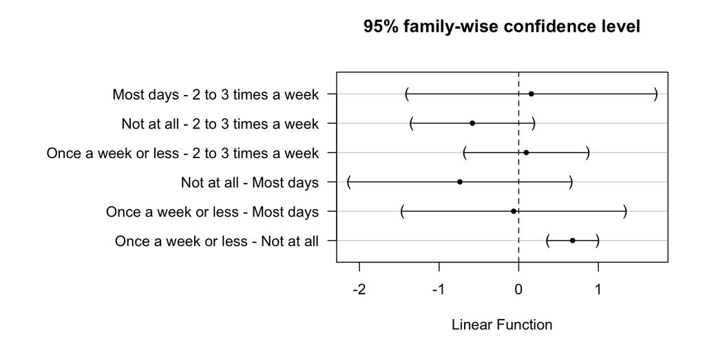

```r
par(oma = c(0, 15, 0, 0))  ## increase left outer margin
plot(glht(mod_drink, linfct = mcp(drink = "Tukey")))
```

## What shall I do?

- Use at least well choosen contrasts

```r
UK$drink2 <- relevel(UK$drink, ref = "Not at all")
summary(mod_drink2 <- lm(height ~ drink2, data = UK))$coef
```

```
##                              Estimate Std. Error     t value     Pr(>|t|)
## (Intercept)               138.2737641 0.08375878 1650.856979 0.000000e+00
## drink22 to 3 times a week   0.5816112 0.30697391    1.894660 5.816199e-02
## drink2Most days             0.7397111 0.55854035    1.324365 1.854077e-01
## drink2Once a week or less   0.6758454 0.12500892    5.406377 6.557008e-08
```

```r
## compare to summary(glht(mod_drink2, linfct = mcp(drink2 = "Dunnett")))
```

## What you need to remember

- how to use the functions `summary()`, `anova()` and `Anova()`
- that parameters are tested using t-tests
- that you can use LM to do usual Student's t-tests and Pearson correlation tests
- that variables are tested using F-tests or Likelihood Ratio Tests
- how to check the statistical robustness of a test
- how to do a LRT by parametric bootstrap
- that type II ANOVA is the way to go for testing variables
- that doing many tests is dangerous

## Table of contents

## The Linear Model: LM

- 2.0 Introduction
- 2.1 Point estimates
- 2.2 Uncertainty in point estimates
- 2.3 Tests
- 2.4 Assumptions and Outliers
- 2.5 Let's practice more